# Tugas Akhir Mandiri TPG

Muthi’ah Iffa Karimah

2025-11-25

# Penerapan Analisis Gerombol Berhierarki (Metode Ward) untuk Pemetaan Stabilitas Harga Komoditas Pangan Pasca-Kebijakan Impor (Studi Kasus: Daging Sapi 2023 dan Beras 2024)

## *Cleaning Data*

```r
library(readr)
library(readxl)
library(psych)
library(GPArotation)
library(factoextra)
```

```r
library(cluster)
library(factoextra)
library(clusterCrit)
library(ggplot2)
library(tidyr)
library(scales)
library(corrplot)
library(cluster)
library(MASS)
library(dplyr)
library(writexl)
```

```r
# data.raw = read_csv("D:\\Semester 5\\TPG\\TPG\\Tugas Akhir Mandiri TPG .csv")
# head(data.raw)
```

```r
# Rapikan data
# data = data.raw %>% separate( col = 1,  into = c("Kabupaten", "Tahun", "Bulan", "Komoditas", "Harga", "Kategori", "Nilai_X", "Nilai_Y", "Provinsi"), sep = ";")
# View(data)
```

```r
# Simpan File
# write_xlsx(data, "Tugas Akhir Mandiri TPG (rapi).xlsx")
```

# Input File

```r
komoditas = read_xlsx("D:\\Semester 5\\TPG\\TPG\\Tugas Akhir Mandiri TPG (rapi).xlsx")
head(komoditas)
```

```
## # A tibble: 6 × 9
##   Kabupaten       Tahun Bulan Komoditas Harga Kategori KodeBPS KodeProv Provinsi
##   <chr>           <chr> <chr> <chr>     <chr> <chr>    <chr>   <chr>    <chr>
## 1 Kota Yogyakarta 2022  Janu… Beras Pr… 10461 Beras    34.71   34       DI Yogy…
## 2 Kota Yogyakarta 2022  Janu… Beras Me… 9461  Beras    34.71   34       DI Yogy…
## 3 Kota Yogyakarta 2022  Janu… Bawang M… 19283 Bawang   34.71   34       DI Yogy…
## 4 Kota Yogyakarta 2022  Janu… Bawang P… 23000 Bawang   34.71   34       DI Yogy…
## 5 Kota Yogyakarta 2022  Janu… Cabai Me… 23968 Cabai    34.71   34       DI Yogy…
## 6 Kota Yogyakarta 2022  Janu… Cabai Ra… 36226 Cabai    34.71   34       DI Yogy…
```

```r
str(komoditas)
```

```
## tibble [340,620 × 9] (S3: tbl_df/tbl/data.frame)
##  $ Kabupaten: chr [1:340620] "Kota Yogyakarta" "Kota Yogyakarta" "Kota Yogyakarta" "Kota Yogyakarta" ...
##  $ Tahun    : chr [1:340620] "2022" "2022" "2022" "2022" ...
##  $ Bulan    : chr [1:340620] "Januari" "Januari" "Januari" "Januari" ...
##  $ Komoditas: chr [1:340620] "Beras Premium" "Beras Medium" "Bawang Merah" "Bawang Putih (Bonggol)" ...
##  $ Harga    : chr [1:340620] "10461" "9461" "19283" "23000" ...
##  $ Kategori : chr [1:340620] "Beras" "Beras" "Bawang" "Bawang" ...
##  $ KodeBPS  : chr [1:340620] "34.71" "34.71" "34.71" "34.71" ...
##  $ KodeProv : chr [1:340620] "34" "34" "34" "34" ...
##  $ Provinsi : chr [1:340620] "DI Yogyakarta" "DI Yogyakarta" "DI Yogyakarta" "DI Yogyakarta" ...
```

```r
# Definisikan Bulan
bulan = c("Januari", "Februari", "Maret", "April", "Mei", "Juni", "Juli", "Agustus", "September", "Oktober", "November", "Desember")

# Ubah peubah menjadi numerik
komoditas = komoditas %>% mutate(
    Harga   = as.numeric(Harga),
    KodeBPS = as.numeric(KodeBPS),
    KodeProv = as.numeric(KodeProv),
    Tahun = as.integer(Tahun), # Ubah tahun integer
    Bulan = factor(Bulan, levels = bulan, ordered = TRUE)
    )
str(komoditas)
```

```
## tibble [340,620 × 9] (S3: tbl_df/tbl/data.frame)
##  $ Kabupaten: chr [1:340620] "Kota Yogyakarta" "Kota Yogyakarta" "Kota Yogyakarta" "Kota Yogyakarta" ...
##  $ Tahun    : int [1:340620] 2022 2022 2022 2022 2022 2022 2022 2022 2022 2022 ...
##  $ Bulan    : Ord.factor w/ 12 levels "Januari"<"Februari"<..: 1 1 1 1 1 1 1 1 1 1 ...
##  $ Komoditas: chr [1:340620] "Beras Premium" "Beras Medium" "Bawang Merah" "Bawang Putih (Bonggol)" ...
##  $ Harga    : num [1:340620] 10461 9461 19283 23000 23968 ...
##  $ Kategori : chr [1:340620] "Beras" "Beras" "Bawang" "Bawang" ...
##  $ KodeBPS  : num [1:340620] 34.7 34.7 34.7 34.7 34.7 ...
##  $ KodeProv : num [1:340620] 34 34 34 34 34 34 34 34 34 34 ...
##  $ Provinsi : chr [1:340620] "DI Yogyakarta" "DI Yogyakarta" "DI Yogyakarta" "DI Yogyakarta" ...
```

```r
nrow(komoditas)
```

```
## [1] 340620
```

# Persiapan Data (*Preprocessing Data*)

## Cek Missing Value

```r
sum.na = colSums(is.na(komoditas))
sum.na
```

```
## Kabupaten     Tahun     Bulan Komoditas     Harga  Kategori   KodeBPS  KodeProv
##         0         0         0         0     61513         0         0         0
##  Provinsi
##         0
```

```r
# cek baris mana saja yang missing value
komoditas$no.baris = 1:nrow(komoditas)

# filter data, mengambil baris yang missing value
tabel.na = komoditas %>% filter(is.na(Harga))
head(tabel.na)
```

```
## # A tibble: 6 × 10
##   Kabupaten       Tahun Bulan Komoditas Harga Kategori KodeBPS KodeProv Provinsi
##   <chr>           <int> <ord> <chr>     <dbl> <chr>      <dbl>    <dbl> <chr>
## 1 Kota Yogyakarta  2022 Janu… Minyak G…    NA MinyakG…    34.7       34 DI Yogy…
## 2 Kota Yogyakarta  2022 Janu… Jagung T…    NA Jagung      34.7       34 DI Yogy…
## 3 Kota Yogyakarta  2022 Janu… Cabai Me…    NA Cabai       34.7       34 DI Yogy…
## 4 Kota Yogyakarta  2022 Janu… Minyakita    NA MinyakG…    34.7       34 DI Yogy…
## 5 Kota Yogyakarta  2022 Febr… Minyak G…    NA MinyakG…    34.7       34 DI Yogy…
## 6 Kota Yogyakarta  2022 Febr… Jagung T…    NA Jagung      34.7       34 DI Yogy…
## # ℹ 1 more variable: no.baris <int>
```

```r
# Lihat provinsi apa saja yang memiliki missing value
provinsi.na = tabel.na %>% count(Provinsi, sort = TRUE)
provinsi.na
```

```
## # A tibble: 34 × 2
##    Provinsi                n
##    <chr>               <int>
##  1 Sumatera Utara       5002
##  2 Jawa Timur           4086
##  3 Aceh                 3979
##  4 Jawa Tengah          3153
##  5 Jawa Barat           2797
##  6 Nusa Tenggara Timur  2610
##  7 Sumatera Barat       2531
##  8 Sulawesi Selatan     2472
##  9 Papua Barat          2390
## 10 Sulawesi Tenggara    2331
## # ℹ 24 more rows
```

### Penanganan Missing Value

Terdapat 61513 *missing value* di dalam peubah Harga, sehingga dilakukan penanganan dengan mengisi *missing value* dengan nilai rataan wilayah tetangganya (terdekat).

```r
komoditas = komoditas %>% mutate(
  Pulau = case_when(
    # SUMATERA (Tetangga Sumut ada di sini)
      Provinsi %in% c("Aceh", "Sumatera Utara", "Sumatera Barat", "Riau", "Kepulauan Riau",
                      "Jambi", "Sumatera Selatan", "Bengkulu", "Lampung", "Kepulauan Bangka Belitung") ~ "Sumatera",

      # JAWA
      Provinsi %in% c("DKI Jakarta", "Jawa Barat", "Jawa Tengah", "DI Yogyakarta", "Jawa Timur", "Banten") ~ "Jawa",

      # BALI & NUSA TENGGARA
      Provinsi %in% c("Bali", "Nusa Tenggara Barat", "Nusa Tenggara Timur") ~ "BaliNusra",

      # KALIMANTAN
      Provinsi %in% c("Kalimantan Barat", "Kalimantan Tengah", "Kalimantan Selatan", "Kalimantan Timur", "Kalimantan Utara") ~ "Kalimantan",

      # SULAWESI
      Provinsi %in% c("Sulawesi Utara", "Gorontalo", "Sulawesi Tengah", "Sulawesi Barat", "Sulawesi Selatan", "Sulawesi Tenggara") ~ "Sulawesi",

      # MALUKU & PAPUA
      Provinsi %in% c("Maluku", "Maluku Utara", "Papua", "Papua Barat", "Papua Barat Daya", "Papua Selatan", "Papua Tengah", "Papua Pegunungan") ~ "MalukuPapua",

            )
)
head(komoditas)
```

```
## # A tibble: 6 × 11
##   Kabupaten       Tahun Bulan Komoditas Harga Kategori KodeBPS KodeProv Provinsi
##   <chr>           <int> <ord> <chr>     <dbl> <chr>      <dbl>    <dbl> <chr>
## 1 Kota Yogyakarta  2022 Janu… Beras Pr… 10461 Beras       34.7       34 DI Yogy…
## 2 Kota Yogyakarta  2022 Janu… Beras Me…  9461 Beras       34.7       34 DI Yogy…
## 3 Kota Yogyakarta  2022 Janu… Bawang M… 19283 Bawang      34.7       34 DI Yogy…
## 4 Kota Yogyakarta  2022 Janu… Bawang P… 23000 Bawang      34.7       34 DI Yogy…
## 5 Kota Yogyakarta  2022 Janu… Cabai Me… 23968 Cabai       34.7       34 DI Yogy…
## 6 Kota Yogyakarta  2022 Janu… Cabai Ra… 36226 Cabai       34.7       34 DI Yogy…
## # ℹ 2 more variables: no.baris <int>, Pulau <chr>
```

**no.baris** adalah nomor baris yang ada di tabel/data “komoditas”, artinya jika di dalam kolom no.baris berisi “12” artinya ada missing value di baris ke 12 dalam tabel/data “komoditas”

```r
# Buat Referensi
# Hitung rataan harga per Kabupaten
ref_kab = komoditas %>%
  group_by(Kabupaten, Komoditas) %>% # mengelompokkan data berdasat Kabupaten dan Komoditas
  summarise(mean_kab = mean(Harga, na.rm = TRUE), .groups = "drop") # menghitung rataan harga dengan mengabaikan missing value (na.rm = TRUE)

# Hitung rataan harga per Provinsi
ref_prov = komoditas %>%
  group_by(Provinsi, Komoditas) %>%
  summarise(mean_prov = mean(Harga, na.rm = TRUE), .groups = "drop")

# Rata-rata harga per Pulau
ref_pulau = komoditas %>%
  group_by(Pulau, Komoditas) %>%
  summarise(mean_pulau = mean(Harga, na.rm = TRUE), .groups = "drop")

# Rata-rata Nasional (Jaring Pengaman Terakhir)
ref_nas <- komoditas %>%
  group_by(Komoditas) %>%
  summarise(mean_nas = mean(Harga, na.rm = TRUE), .groups = "drop")
```

```r
# Menyandingkan referensi ke tabel utama
komoditas_ref = komoditas %>%
  # Gabungkan semua tabel referensi ke data utama
  left_join(ref_kab, by = c("Kabupaten", "Komoditas")) %>%
  left_join(ref_prov, by = c("Provinsi", "Komoditas")) %>%
  left_join(ref_pulau, by = c("Pulau", "Komoditas")) %>%
  left_join(ref_nas, by = "Komoditas") %>%
  # Lakukan pengisian dengan urutan prioritas
  mutate(
    Harga_Fix = coalesce(Harga,        # Cek Harga Asli
                         mean_kab,     # jika kosong, pakai Rataan Kabupaten
                        mean_prov,    # jika kosong, pakai Rataan Provinsi
                         mean_pulau,   # jika kosong, pakai Rataan Pulau (Tetangga)
                         mean_nas))     # terakhir pakai Rataan Nasional
str(komoditas_ref)
```

```
## tibble [340,620 × 16] (S3: tbl_df/tbl/data.frame)
##  $ Kabupaten : chr [1:340620] "Kota Yogyakarta" "Kota Yogyakarta" "Kota Yogyakarta" "Kota Yogyakarta" ...
##  $ Tahun     : int [1:340620] 2022 2022 2022 2022 2022 2022 2022 2022 2022 2022 ...
##  $ Bulan     : Ord.factor w/ 12 levels "Januari"<"Februari"<..: 1 1 1 1 1 1 1 1 1 1 ...
##  $ Komoditas : chr [1:340620] "Beras Premium" "Beras Medium" "Bawang Merah" "Bawang Putih (Bonggol)" ...
##  $ Harga     : num [1:340620] 10461 9461 19283 23000 23968 ...
##  $ Kategori  : chr [1:340620] "Beras" "Beras" "Bawang" "Bawang" ...
##  $ KodeBPS   : num [1:340620] 34.7 34.7 34.7 34.7 34.7 ...
##  $ KodeProv  : num [1:340620] 34 34 34 34 34 34 34 34 34 34 ...
##  $ Provinsi  : chr [1:340620] "DI Yogyakarta" "DI Yogyakarta" "DI Yogyakarta" "DI Yogyakarta" ...
##  $ no.baris  : int [1:340620] 1 2 3 4 5 6 7 8 9 10 ...
##  $ Pulau     : chr [1:340620] "Jawa" "Jawa" "Jawa" "Jawa" ...
##  $ mean_kab  : num [1:340620] 12906 11735 29793 29858 38796 ...
##  $ mean_prov : num [1:340620] 13344 11992 34031 31323 39779 ...
##  $ mean_pulau: num [1:340620] 13575 11935 34743 32551 43209 ...
##  $ mean_nas  : num [1:340620] 14541 12754 37651 36396 48740 ...
##  $ Harga_Fix : num [1:340620] 10461 9461 19283 23000 23968 ...
```

Harga = data asli (raw) original dari file excel yang masih memiliki banyak *missing value*

mean_kab/_prov/*pulau = mean yang diambil dari tiap kabupaten, provinsi, dan pulau.* (Jika rataan kabupaten kosong, maka rataan prov kosong, maka rataan pulau juga kosong)

mean_nas = rataan nasional

Harga_FIx = hasil akhir, jika harga asli ada akan dipakai, jika tidak maka akan otomatis memakai harga dari nilai referensi tadi sesuai dengan urutan prioritas

no.baris = nomor urut baris sesuai data asli di excel untuk melacak kembali data yang mengandung *missing value*

### Finalisasi Data

```r
# Mengisi missing value pada kolom harga dengan nilai rataan dari referensi
komoditas_final = komoditas_ref %>%
  mutate(Harga = Harga_Fix) %>%
  select(-mean_kab, -mean_prov, -mean_pulau, -mean_nas, -Harga_Fix, -no.baris)

str(komoditas_final)
```

```
## tibble [340,620 × 10] (S3: tbl_df/tbl/data.frame)
##  $ Kabupaten: chr [1:340620] "Kota Yogyakarta" "Kota Yogyakarta" "Kota Yogyakarta" "Kota Yogyakarta" ...
##  $ Tahun    : int [1:340620] 2022 2022 2022 2022 2022 2022 2022 2022 2022 2022 ...
##  $ Bulan    : Ord.factor w/ 12 levels "Januari"<"Februari"<..: 1 1 1 1 1 1 1 1 1 1 ...
##  $ Komoditas: chr [1:340620] "Beras Premium" "Beras Medium" "Bawang Merah" "Bawang Putih (Bonggol)" ...
##  $ Harga    : num [1:340620] 10461 9461 19283 23000 23968 ...
##  $ Kategori : chr [1:340620] "Beras" "Beras" "Bawang" "Bawang" ...
##  $ KodeBPS  : num [1:340620] 34.7 34.7 34.7 34.7 34.7 ...
##  $ KodeProv : num [1:340620] 34 34 34 34 34 34 34 34 34 34 ...
##  $ Provinsi : chr [1:340620] "DI Yogyakarta" "DI Yogyakarta" "DI Yogyakarta" "DI Yogyakarta" ...
##  $ Pulau    : chr [1:340620] "Jawa" "Jawa" "Jawa" "Jawa" ...
```

```r
# cek missing value pada data final
colSums(is.na(komoditas_final))
```

```
## Kabupaten     Tahun     Bulan Komoditas     Harga  Kategori   KodeBPS  KodeProv
##         0         0         0         0         0         0         0         0
##  Provinsi     Pulau
##         0      3450
```

```r
# Perbaikan kolom Provinsi
komoditas_final = komoditas_final %>% mutate(
  Provinsi = case_when(KodeProv == 65 ~ "Kalimantan Utara", # mengubah KodeProv 65 menjadi "Kalimantan Utara"
                       TRUE ~ Provinsi), # sisanya biarkan
  Pulau = case_when(
    Provinsi == "Kalimantan Utara" ~ "Kalimantan", # jika provinsi sudah terisi, isi pulaunya menjadi "Kalimantan"
    TRUE ~ Pulau # sisanya biarkan
  )
)

# Cek hasil perbaikan
kaltara = komoditas_final %>%
  filter(KodeProv == 65) %>%  # <--- Tanda pipe ini yang tadi kurang
  select(Kabupaten, Provinsi, Pulau) %>%
  distinct() # Ambil data unik saja

kaltara
```

```
## # A tibble: 5 × 3
##   Kabupaten        Provinsi         Pulau
##   <chr>            <chr>            <chr>
## 1 Kota Tarakan     Kalimantan Utara Kalimantan
## 2 Kab. Tana Tidung Kalimantan Utara Kalimantan
## 3 Kab. Nunukan     Kalimantan Utara Kalimantan
## 4 Kab. Malinau     Kalimantan Utara Kalimantan
## 5 Kab. Bulungan    Kalimantan Utara Kalimantan
```

```r
colSums(is.na(komoditas_final))
```

```
## Kabupaten     Tahun     Bulan Komoditas     Harga  Kategori   KodeBPS  KodeProv
##         0         0         0         0         0         0         0         0
##  Provinsi     Pulau
##         0         0
```

data provinsi dan pulau sudah bersih

```r
# Export file ke excel
# write_xlsx(komoditas_final, "Tugas Akhir Mandiri TPG (clean).xlsx")
```

# Analisis Klastering

Pada analisis ini akan dilakukan analisis klastering secara terpisah pada komoditas beras dan daging sapi.

1. studi kasus 1: Daging Sapi (2023) –> fokus melihat stabilitas harga daging saat impor daging tertinggi
2. studi kasus 2: Beras (2024) –> fokus melihat stabilitas harga beras saat impor beras tertinggi

#### Metode Hierarki (Ward)

$$JKS = \sum_j^n (x_j - \bar{x})'(x_j
- \bar{x})$$

$$atau$$

$$ESS = \sum_i^n (x_i -
\bar{x})^2$$

Menentukan klaster dengan metode hierarki dengan *Ward’s Method* karena metode ini bertujuan untuk mendapatkan klaster dengan varians sekecil mungkin (Matdoan et al., 2023) dan meminimalkan hilangnya informasi akibat penggabungan objek menjadi klaster (Hernanto et al., 2017).

1. **Menghasilkan klaster yang homogen**: metode ini meminimumkan varians (ragam) dalam klaster sehingga klaster yang terbentuk nantinya akan benar-benar memiliki harga yang sangat mirip.
2. **Sensitif Terhadap Ukuran Kelompok**: cenderung menghasilkan klaster dengan ukuran yang relatif seimbang, misal: klaster 1 = 10, klaster 2 = 15, klaster 3 = 9.
3. **Dasar Matematis**: metode ward bekerja dengan meminimumkan varians. Pada analisis ini digunakan Standar Deviasi untuk hitung *price instability* maka data saya cocok untuk diterapkan metode ward

```r
komo_clean = read_xlsx("D:\\Semester 5\\TPG\\TPG\\Tugas Akhir Mandiri TPG (clean).xlsx")
View(komo_clean)
str(komo_clean)
```

```
## tibble [340,620 × 10] (S3: tbl_df/tbl/data.frame)
##  $ Kabupaten: chr [1:340620] "Kota Yogyakarta" "Kota Yogyakarta" "Kota Yogyakarta" "Kota Yogyakarta" ...
##  $ Tahun    : num [1:340620] 2022 2022 2022 2022 2022 ...
##  $ Bulan    : chr [1:340620] "Januari" "Januari" "Januari" "Januari" ...
##  $ Komoditas: chr [1:340620] "Beras Premium" "Beras Medium" "Bawang Merah" "Bawang Putih (Bonggol)" ...
##  $ Harga    : num [1:340620] 10461 9461 19283 23000 23968 ...
##  $ Kategori : chr [1:340620] "Beras" "Beras" "Bawang" "Bawang" ...
##  $ KodeBPS  : num [1:340620] 34.7 34.7 34.7 34.7 34.7 ...
##  $ KodeProv : num [1:340620] 34 34 34 34 34 34 34 34 34 34 ...
##  $ Provinsi : chr [1:340620] "DI Yogyakarta" "DI Yogyakarta" "DI Yogyakarta" "DI Yogyakarta" ...
##  $ Pulau    : chr [1:340620] "Jawa" "Jawa" "Jawa" "Jawa" ...
```

```r
colSums(is.na(komo_clean))
```

```
## Kabupaten     Tahun     Bulan Komoditas     Harga  Kategori   KodeBPS  KodeProv
##         0         0         0         0         0         0         0         0
##  Provinsi     Pulau
##         0         0
```

## 1. Studi kasus 1: Stabilitas Harga Daging Sapi Murni (2023)

### Preprocessing Data

```r
# SD harga daging sapi murni tiap provinsi
sd_gejolak_d = sd(komo_clean$Harga[komo_clean$Tahun == 2023 &
                                komo_clean$Komoditas == "Daging Sapi Murni"], na.rm = TRUE)

# Indikator ketidakstabilan harga (Standar Deviasi)
daging = komo_clean %>%
  filter(Tahun == 2023,
         Komoditas == "Daging Sapi Murni") %>%
  group_by(Provinsi) %>%
  summarise(
    sd_gejolak_d = sd(Harga, na.rm = TRUE), # indikator ketidakstabilan
    .groups = "drop"
  )
daging
```

```
## # A tibble: 34 × 2
##    Provinsi      sd_gejolak_d
##    <chr>                <dbl>
##  1 Aceh                 9355.
##  2 Bali                 3739.
##  3 Banten               5782.
##  4 Bengkulu             6194.
##  5 DI Yogyakarta        4365.
##  6 DKI Jakarta          4695.
##  7 Gorontalo            4991.
##  8 Jambi                6405.
##  9 Jawa Barat           5311.
## 10 Jawa Tengah          6466.
## # ℹ 24 more rows
```

Bersihkan data dengan harga daging yang konstan (*flat*) karena jika harganya tetap, maka SD nya pun akan nol.

```r
# Bersikan data dengan harga yang konstan
daging$sd_gejolak_d [is.na(daging$sd_gejolak_d )] = 0 # paksa menjadi 0 (provinsi dengan nilai tersebut dianggap stabil)
```

### EDA (*Exploratory Data Analysis*)

#### Statistik

```r
# Statistik data daging
summary(daging)
```

```
##    Provinsi          sd_gejolak_d
##  Length:34          Min.   : 3184
##  Class :character   1st Qu.: 5885
##  Mode  :character   Median : 7829
##                     Mean   : 8403
##                     3rd Qu.:10098
##                     Max.   :18404
```

#### Bar Chart

```r
# Sertakan nilai max dan min dari instability price daging
max = max(daging$sd_gejolak_d)
min = min(daging$sd_gejolak_d)

# Hasil
cat("Max : Rp", format(max, big.mark = ".", decimal.mark = ","), "\n")
```

```
## Max : Rp 18.403,56
```

```r
cat("Min : Rp", format(min, big.mark = ".", decimal.mark = ","), "\n")
```

```
## Min : Rp 3.183,555
```

```r
cat("Standar Deviasi   : Rp", format(sd_gejolak_d, big.mark = ".", decimal.mark = ","), "\n")
```

```
## Standar Deviasi   : Rp 15.341,4
```

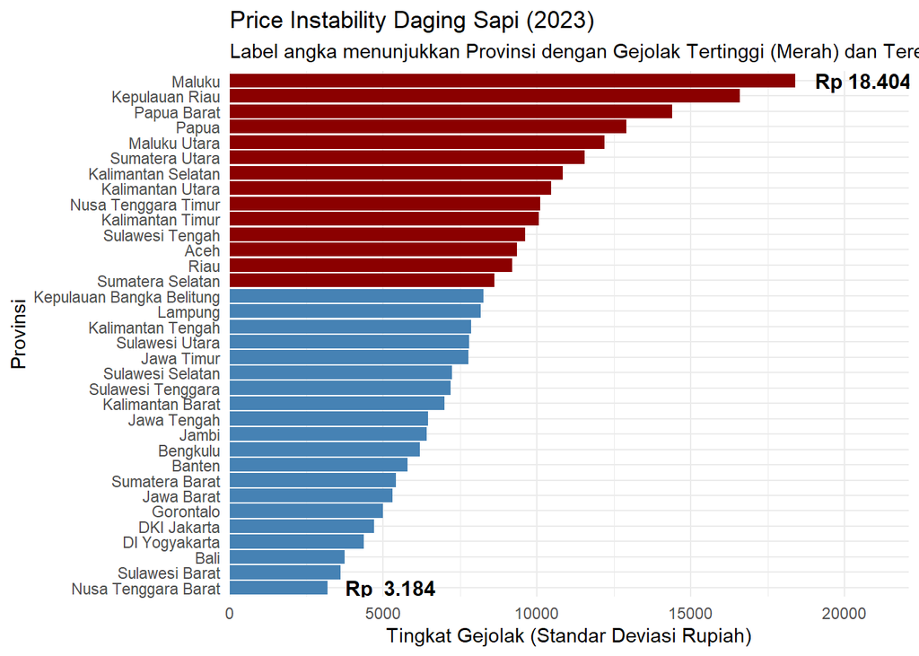

```r
# Bar Chart untuk mengetahui tingkatan lonjakan
ggplot(daging, aes(x = reorder(Provinsi, sd_gejolak_d), y = sd_gejolak_d)) +
  geom_bar(stat = "identity", fill = ifelse(daging$sd_gejolak_d > mean(daging$sd_gejolak_d), "darkred", "steelblue")) +
  coord_flip() +

  geom_text(data = subset(daging, sd_gejolak_d == max | sd_gejolak_d == min),
            aes(label = paste0("Rp ", format(round(sd_gejolak_d, 0), big.mark = ".", scientific = FALSE))),
            hjust = -0.2,        # Geser teks ke kanan sedikit biar tidak nempel batang
            color = "black",     # Warna teks
            fontface = "bold",   # Teks tebal
            size = 4) +          # Ukuran teks

  # Menambah ruang kosong di sebelah kanan agar teks tidak terpotong
  scale_y_continuous(expand = expansion(mult = c(0, 0.2))) +

  labs(
    title = "Price Instability Daging Sapi (2023)",
    subtitle = "Label angka menunjukkan Provinsi dengan Gejolak Tertinggi (Merah) dan Terendah (Biru)",
    x = "Provinsi",
    y = "Tingkat Gejolak (Standar Deviasi Rupiah)"
  ) +
  theme_minimal()
```

Terlihat bahwa Maluku menjadi provinsi dengan nilai gejolak harga daging sapi tertinggi dengan nilai Rp 18.404 dan NTB menjadi provinsi dengan gejolak harga daging sapi terendah dengan nilai Rp 3.184.

#### Boxplot

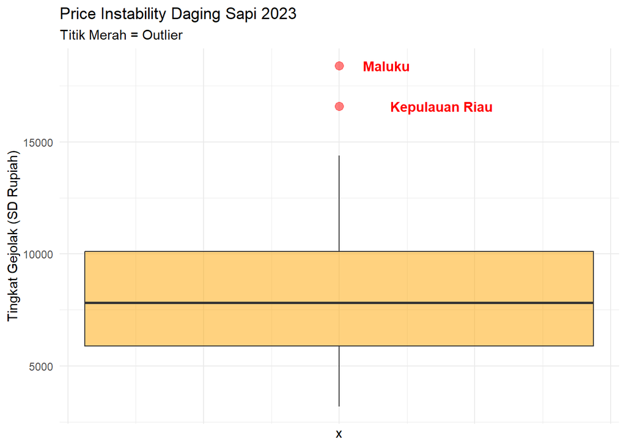

```r
# Boxplot untuk mengetahui outlier
ggplot(daging, aes(y = sd_gejolak_d)) +

# Tambahkan outlier.colour = "red" di sini
geom_boxplot(fill = "orange", alpha = 0.5, outlier.colour = "red", outlier.shape = 19, outlier.size = 3) +

# Label Teks untuk Outlier
geom_text(data = subset(daging, sd_gejolak_d > quantile(sd_gejolak_d, 0.75) + 1.5 * IQR(sd_gejolak_d)),
            aes(label = Provinsi, x = 0),
            hjust = -0.5, color = "red", fontface = "bold") +

  labs(
    title = "Price Instability Daging Sapi 2023",
    subtitle = "Titik Merah = Outlier",
    y = "Tingkat Gejolak (SD Rupiah)"
  ) +
  theme_minimal() +
  theme(axis.text.x = element_blank(), axis.ticks.x = element_blank())
```

Terlihat bahwa terdapat 2 outlier yaitu Prov. Maluku dan Prov. Kep. Riau.

### Metode Ward

#### Standarisasi Data

Tidak perlu standarisasi data karena variabel yang digunakan hanya 1 saja yaitu kolom “gejolak_id”.

```r
# Matriks data
matrix_d = as.data.frame(daging)
rownames(matrix_d) = matrix_d$Provinsi # nama provinsi jadi label baris
matrix_d = matrix_d[,"sd_gejolak_d", drop = FALSE] # mengambil kolom dengan angka saja

# Hitung jarak Euclidean) data asli
euc_d = dist(matrix_d,  method = "euclidean")

# Pohon klaster dengan Metode Ward
klaster_d = hclust(euc_d, method = "ward.D2")
```

#### Visualisasi

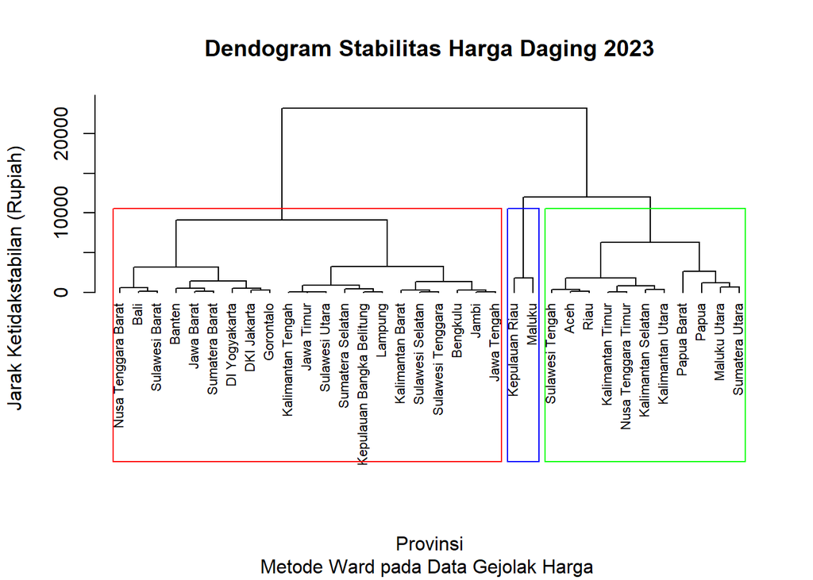

```r
plot(klaster_d,
     main = "Dendogram Stabilitas Harga Daging 2023",
     sub = "Metode Ward pada Data Gejolak Harga ",
     xlab = "Provinsi",
     ylab = "Jarak Ketidakstabilan (Rupiah)",
     hang = -1,  # Label sejajar di bawah
     cex = 0.7)  # Ukuran font
rect.hclust(klaster_d, k = 3, border = c("red", "blue", "green")) # bagi jadi 2 klaster
```

#### Profiling

Mengetahui klaster-klaster tersebut seperti apa tingkat ketidakstabilannya

```r
# Potong klaster sesuai dengan peta pohon
anggota_klaster_d = cutree(klaster_d, k = 3)

# Gabungkan hasil klaster ke data gejolak
hasil_klaster_d = data.frame(
  Provinsi = rownames(matrix_d),
  Gejolak_Rupiah = matrix_d$sd_gejolak_d, # Data Asli (SD)
  Klaster = as.factor(anggota_klaster_d) # Label 1, 2, 3
)

# Hitung statistik tiap klaster
profil_klaster_d = hasil_klaster_d %>%
  group_by(Klaster) %>%
  summarise(
    Jumlah_Provinsi = n(),
    Rata2_Gejolak = mean(Gejolak_Rupiah),
    Min_Gejolak = min(Gejolak_Rupiah),
    Max_Gejolak = max(Gejolak_Rupiah),
    Anggota = paste(Provinsi, collapse = ", ")
  ) %>%
  arrange(desc(Rata2_Gejolak)) %>% # Urutkan dari Rata-rata Tertinggi (Paling Bahaya)

# labeling klaster
mutate(
    Kategori = case_when(
      row_number() == 1 ~ "ZONA MERAH (Bahaya)",
      row_number() == 2 ~ "ZONA KUNING (Waspada)",
      row_number() == 3 ~ "ZONA HIJAU (Aman)"
    ),
  Rataan_Gejolak = paste("Rp", format(round(Rata2_Gejolak, 0), big.mark = ".", decimal.mark = ","))
  ) %>%
  select (Klaster, Kategori, Rataan_Gejolak, Anggota)
```

```r
library(gt)
tabel_ringkas = profil_klaster_d %>%
  gt() %>%

  # Judul
  tab_header(
    title = md("Profil Klaster Stabilitas Harga Daging Sapi 2023"),
    subtitle = "Clustering Provinsi Berdasarkan Tingkat Gejolak Harga"
  ) %>%

  cols_label(
    Klaster = "Klaster",
    Kategori = "Kategori Risiko",
    Rataan_Gejolak = "Rata-rata Gejolak",
    Anggota = "Daftar Provinsi Anggota"
  ) %>%

  cols_width(
    Rataan_Gejolak ~ px(150),
    Anggota ~ px(400),
    Kategori ~ px(150)
  ) %>%

    tab_options(
    table.border.top.color = "black",
    heading.border.bottom.color = "black",
    column_labels.border.bottom.color = "black"
  )

# Tampilkan
tabel_ringkas
```

Profil Klaster Stabilitas Harga Daging Sapi 2023

Clustering Provinsi Berdasarkan Tingkat Gejolak Harga

| Klaster | Kategori Risiko | Rata-rata Gejolak | Daftar Provinsi Anggota |
| --- | --- | --- | --- |
| 3 | ZONA MERAH (Bahaya) | Rp 17.500 | Kepulauan Riau, Maluku |
| 1 | ZONA KUNING (Waspada) | Rp 10.970 | Aceh, Kalimantan Selatan, Kalimantan Timur, Kalimantan Utara, Maluku Utara, Nusa Tenggara Timur, Papua, Papua Barat, Riau, Sulawesi Tengah, Sumatera Utara |
| 2 | ZONA HIJAU (Aman) | Rp 6.192 | Bali, Banten, Bengkulu, DI Yogyakarta, DKI Jakarta, Gorontalo, Jambi, Jawa Barat, Jawa Tengah, Jawa Timur, Kalimantan Barat, Kalimantan Tengah, Kepulauan Bangka Belitung, Lampung, Nusa Tenggara Barat,… |

Dari hasil analisis klaster pada studi kasus 1 yang telah dilakukan terlihat bahwa wilayah/provinsi yang padat penduduk atau menjadi pusat ekonomi memiliki stabilitas harga yang cukup terkontrol dibandingkan dengan wilayah yang bukan merupakan pusat ekonomi dan relatif tidak padat penduduk.

Hal ini mungkin terjadi karena **masalah distribus**i pada daerah-daerah yang jauh, **struktur pasar oligopoli**, **ketergantungan pasokan** karena bukan sentra produksi, atau **keterhambatan infrastruktur (cold chain).**

### Analisis Diskriminan

```r
# Gabungkan data dengan label
validasi_d = hasil_klaster_d %>%
  left_join(profil_klaster_d %>% select(Klaster,Kategori), by = "Klaster") %>%
  select(Gejolak_Rupiah, Kategori)
```

```r
# LDA
model_lda_d = lda(Kategori ~ Gejolak_Rupiah, data = validasi_d)
model_lda_d
```

```
## Call:
## lda(Kategori ~ Gejolak_Rupiah, data = validasi_d)
##
## Prior probabilities of groups:
##     ZONA HIJAU (Aman) ZONA KUNING (Waspada)   ZONA MERAH (Bahaya)
##            0.61764706            0.32352941            0.05882353
##
## Group means:
##                       Gejolak_Rupiah
## ZONA HIJAU (Aman)           6192.276
## ZONA KUNING (Waspada)      10969.676
## ZONA MERAH (Bahaya)        17499.556
##
## Coefficients of linear discriminants:
##                         LD1
## Gejolak_Rupiah 0.0006096999
```

```r
# Cek Akurasi
prediksi_d = predict(model_lda_d)$class
conf_matrix_d = table(Aktual = validasi_d$Kategori, Prediksi = prediksi_d)
print(prediksi_d)
```

```
##  [1] ZONA KUNING (Waspada) ZONA HIJAU (Aman)     ZONA HIJAU (Aman)
##  [4] ZONA HIJAU (Aman)     ZONA HIJAU (Aman)     ZONA HIJAU (Aman)
##  [7] ZONA HIJAU (Aman)     ZONA HIJAU (Aman)     ZONA HIJAU (Aman)
## [10] ZONA HIJAU (Aman)     ZONA HIJAU (Aman)     ZONA HIJAU (Aman)
## [13] ZONA KUNING (Waspada) ZONA HIJAU (Aman)     ZONA KUNING (Waspada)
## [16] ZONA KUNING (Waspada) ZONA HIJAU (Aman)     ZONA MERAH (Bahaya)
## [19] ZONA HIJAU (Aman)     ZONA MERAH (Bahaya)   ZONA KUNING (Waspada)
## [22] ZONA HIJAU (Aman)     ZONA KUNING (Waspada) ZONA KUNING (Waspada)
## [25] ZONA KUNING (Waspada) ZONA KUNING (Waspada) ZONA HIJAU (Aman)
## [28] ZONA HIJAU (Aman)     ZONA KUNING (Waspada) ZONA HIJAU (Aman)
## [31] ZONA HIJAU (Aman)     ZONA HIJAU (Aman)     ZONA HIJAU (Aman)
## [34] ZONA KUNING (Waspada)
## Levels: ZONA HIJAU (Aman) ZONA KUNING (Waspada) ZONA MERAH (Bahaya)
```

```r
akurasi_d = sum(diag(conf_matrix_d)) / sum(conf_matrix_d) * 100
cat("Akurasi Klasifikasi Daging :", round(akurasi_d, 2), "%\n\n")
```

```
## Akurasi Klasifikasi Daging : 100 %
```

[figure not shown]

```r
# Visualisasi
library(ggplot2)

# Pastikan data_validasi_daging sudah ada dari langkah sebelumnya
# Plot Distribusi Pemisah Zona
ggplot(validasi_d, aes(x = Gejolak_Rupiah, fill = Kategori)) +
  # Gambar kurva gunung (Density)
  geom_density(alpha = 0.7) +

  # Warna Manual (Biar sesuai konteks: Hijau, Kuning, Merah)
  scale_fill_manual(values = c(
    "ZONA HIJAU (Aman)" = "forestgreen",
    "ZONA KUNING (Waspada)" = "gold",
    "ZONA MERAH (Bahaya)" = "firebrick"
  )) +

  # Hiasan Grafik
  labs(
    title = "Bukti Validitas Pengelompokan Zona Daging Sapi",
    subtitle = "Terlihat kurva Hijau, Kuning, dan Merah terpisah sempurna (Tidak tumpang tindih)",
    x = "Tingkat Gejolak Harga (SD Rupiah)",
    y = "Densitas (Kepadatan Data)",
    fill = "Kategori Zona"
  ) +
  theme_minimal() +
  theme(legend.position = "bottom")
```

Akurasi 100% dipengaruhi oleh data yang *univariate*. Ward membagi-bagi data dengan memotong rentang nilai, karena data daging univariate maka *cut-off-point* **mudah ditemukan.**

## 2. Studi Kasus 2: Stabilitas Harga Beras (2024)

### Preprocessing Data

```r
# Buat data beras
sd_beras_prov = komo_clean %>%
  filter(Tahun == 2024,
         Komoditas %in% c("Beras Premium", "Beras Medium")) %>%
  group_by(Provinsi, Komoditas) %>% # SD dari harga-harga harian/bulanan untuk setiap Provinsi dan Jenis Beras (Premium/Medium).
  summarise(
    sd_gejolak_b = sd(Harga, na.rm = TRUE),
    .groups = "drop"
  ) %>%
  pivot_wider(names_from = Komoditas, values_from = sd_gejolak_b) # pivot jadi 2 kolom (Bivariat)

head(sd_beras_prov)
```

```
## # A tibble: 6 × 3
##   Provinsi      `Beras Medium` `Beras Premium`
##   <chr>                  <dbl>           <dbl>
## 1 Aceh                    682.            610.
## 2 Bali                    750.            571.
## 3 Banten                  944.            948.
## 4 Bengkulu                599.            874.
## 5 DI Yogyakarta           794.            730.
## 6 DKI Jakarta            1297.           1457.
```

```r
sd_beras_nas = komo_clean %>%
  filter(Tahun == 2024,
         Komoditas %in% c("Beras Premium", "Beras Medium")) %>%
  group_by(Komoditas) %>% # <--- Kuncinya di sini: Cuma group by Komoditas
  summarise(
    SD_Nasional = sd(Harga, na.rm = TRUE)
  )

sd_beras_nas
```

```
## # A tibble: 2 × 2
##   Komoditas     SD_Nasional
##   <chr>               <dbl>
## 1 Beras Medium        2158.
## 2 Beras Premium       2560.
```

```r
# Cleaning data
sd_beras_prov[is.na(sd_beras_prov)] = 0

# Data frame
plot_beras = sd_beras_prov

# Matriks
matrix_b = as.data.frame(sd_beras_prov)
rownames(matrix_b) = matrix_b$Provinsi
matrix_b = matrix_b[,-1]
```

### EDA

```r
# Hitung rataan nasional sebagai garis batas
mean_bp = mean(plot_beras$`Beras Premium`)
mean_bm = mean(plot_beras$`Beras Medium`)

# Kode Provinsi
kode_prov = komo_clean %>% select(Provinsi, KodeProv) %>% distinct()
plot_beras_prov = plot_beras %>% left_join(kode_prov, by = "Provinsi")
```

#### Statistik

```r
summary(sd_beras_prov)
```

```
##    Provinsi          Beras Medium    Beras Premium
##  Length:34          Min.   : 531.3   Min.   : 483.8
##  Class :character   1st Qu.: 785.2   1st Qu.: 732.2
##  Mode  :character   Median : 956.5   Median : 850.8
##                     Mean   :1140.4   Mean   :1133.6
##                     3rd Qu.:1073.2   3rd Qu.:1006.9
##                     Max.   :8075.5   Max.   :9813.0
```

```r
summary(sd_beras_nas)
```

```
##   Komoditas          SD_Nasional
##  Length:2           Min.   :2158
##  Class :character   1st Qu.:2259
##  Mode  :character   Median :2359
##                     Mean   :2359
##                     3rd Qu.:2460
##                     Max.   :2560
```

Hasil statistik dari data beras akan lebih baik membutuhkan standarisasi untuk penyamaan skala.

#### Scatter Plot

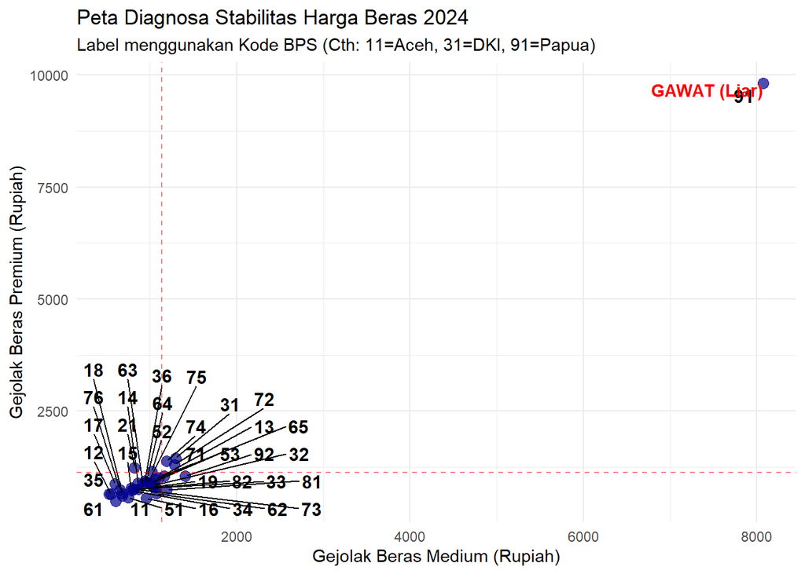

```r
library(ggrepel)

ggplot(plot_beras_prov, aes(x = `Beras Medium`, y = `Beras Premium`)) +

  # Titik Provinsi
  geom_point(color = "darkblue", size = 3, alpha = 0.7) +

  geom_text_repel(aes(label = KodeProv),
                  size = 4,             # Ukuran angka bisa agak besar karena pendek
                  fontface = "bold",
                  box.padding = 0.3,
                  max.overlaps = Inf) +

  # Garis Kuadran
  geom_vline(xintercept = mean_bm, linetype = "dashed", color = "red", alpha=0.5) +
  geom_hline(yintercept = mean_bp, linetype = "dashed", color = "red", alpha=0.5) +

  # Label Penjelas
  annotate("text", x = max(plot_beras$`Beras Medium`), y = max(plot_beras$`Beras Premium`),
           label = "GAWAT (Liar)", color = "red", fontface = "bold", hjust = 1, vjust = 1) +

  labs(
    title = "Peta Diagnosa Stabilitas Harga Beras 2024",
    subtitle = "Label menggunakan Kode BPS (Cth: 11=Aceh, 31=DKI, 91=Papua)",
    x = "Gejolak Beras Medium (Rupiah)",
    y = "Gejolak Beras Premium (Rupiah)"
  ) +
  theme_minimal()
```

Diagnosis awal menunjukkan bahwa sebagian besar/cenderung semua provinsi memiliki harga yang relatif cukup stabil baik beras premium ataupun beras medium.

#### Boxplot

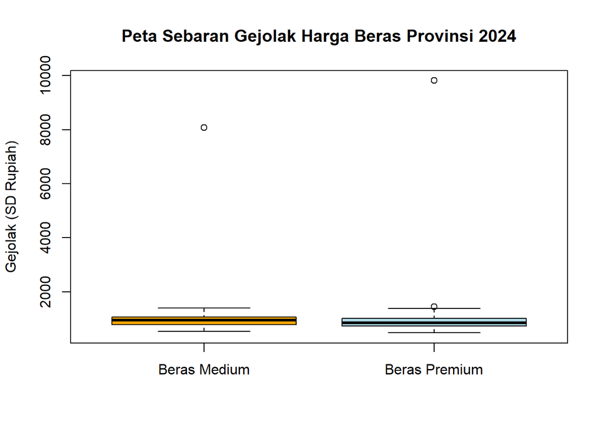

```r
# Boxplot standar deviasi harga beras provinsi
boxplot(matrix_b,
        main = "Peta Sebaran Gejolak Harga Beras Provinsi 2024",
        col = c("orange", "lightblue"),
        ylab = "Gejolak (SD Rupiah)")
```

#### Korelasi

```r
# Korelasi
cat("korelasi:", cor(matrix_b$`Beras Premium`, matrix_b$`Beras Medium`),"\n\n")
```

```
## korelasi: 0.9902987
```

```r
# 5 Provinsi paling rentan ketidakstabilan harga beras
top5 = head(sort(rowSums(matrix_b), decreasing = TRUE), 5)
data.frame(Total_Gejolak = top5)
```

```
##                   Total_Gejolak
## Papua Barat           17888.437
## DKI Jakarta            2754.127
## Sulawesi Tengah        2586.810
## Sulawesi Tenggara      2573.526
## Papua                  2454.565
```

### Metode Ward

#### Standarisasi

```r
beras_scaled = scale(matrix_b)
summary(beras_scaled)
```

```
##   Beras Medium      Beras Premium
##  Min.   :-0.48904   Min.   :-0.41883
##  1st Qu.:-0.28521   1st Qu.:-0.25871
##  Median :-0.14763   Median :-0.18229
##  Mean   : 0.00000   Mean   : 0.00000
##  3rd Qu.:-0.05392   3rd Qu.:-0.08163
##  Max.   : 5.56851   Max.   : 5.59487
```

#### Visualisasi

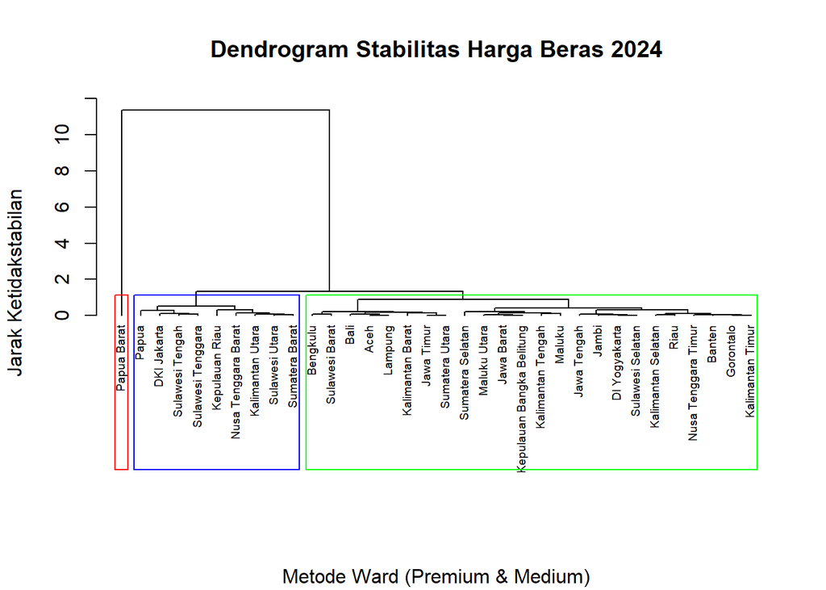

```r
# Jarak Euclidean dan dendogram
euc_b = dist(beras_scaled, method = "euclidean")
dendogram_b = hclust(euc_b, metho = "ward.D2")

# Visualisasi
plot(dendogram_b,
     main = "Dendrogram Stabilitas Harga Beras 2024",
     sub = "Metode Ward (Premium & Medium)",
     xlab = "", ylab = "Jarak Ketidakstabilan",
     hang = -1, cex = 0.6)

rect.hclust(dendogram_b, k = 3, border = c("red", "blue", "green"))
```

#### Profiling

```r
klaster_b = cutree(dendogram_b, k = 3)

# Penggabungan data asli dengan hasil klaster
gab_b = data.frame(
  Provinsi = rownames(matrix_b),
  Premium  = matrix_b$`Beras Premium`,
  Medium   = matrix_b$`Beras Medium`,
  Klaster  = as.factor(klaster_b)
)
```

```r
# Buat data profil
profil_beras = gab_b %>%
  mutate(total_gejolak = Premium + Medium) %>%
  group_by(Klaster) %>%
  summarise(
    jml_prov = n(),
    sd_mean_bp  = mean(Premium),
    sd_mean_bm  = mean(Medium),
    mean_tot = mean(total_gejolak),
    Anggota  = paste(Provinsi, collapse = ", ")
  ) %>%
  arrange(desc(mean_tot)) %>%

  # Label dan Format Rupiah
  mutate(
    Kategori = case_when(
      row_number() == 1 ~ "ZONA MERAH (Bahaya)",
      row_number() == 2 ~ "ZONA KUNING (Waspada)",
      row_number() == 3 ~ "ZONA HIJAU (Aman)"
    ),
    # Panggil nama variabel yang BENAR (mean_bp dan mean_bm)
    `Rataan Beras Premium` = paste("Rp", format(round(sd_mean_bp, 0), big.mark = ".", decimal.mark = ",")),
    `Rataan Beras Medium`  = paste("Rp", format(round(sd_mean_bm, 0), big.mark = ".", decimal.mark = ","))
  ) %>%

  # Pilih kolom yang mau ditampilkan
  select(Klaster, Kategori, `Rataan Beras Premium`, `Rataan Beras Medium`, Anggota)

# Tampilkan
profil_beras %>%
  gt() %>%
  tab_header(title = md("**Rekapitulasi Klaster Beras 2024**")) %>%
  cols_width(Anggota ~ px(400))
```

**Rekapitulasi Klaster Beras 2024**

| Klaster | Kategori | Rataan Beras Premium | Rataan Beras Medium | Anggota |
| --- | --- | --- | --- | --- |
| 3 | ZONA MERAH (Bahaya) | Rp 9.813 | Rp 8.075 | Papua Barat |
| 2 | ZONA KUNING (Waspada) | Rp 1.181 | Rp 1.151 | DKI Jakarta, Kalimantan Utara, Kepulauan Riau, Nusa Tenggara Barat, Papua, Sulawesi Tengah, Sulawesi Tenggara, Sulawesi Utara, Sumatera Barat |
| 1 | ZONA HIJAU (Aman) | Rp 754 | Rp 848 | Aceh, Bali, Banten, Bengkulu, DI Yogyakarta, Gorontalo, Jambi, Jawa Barat, Jawa Tengah, Jawa Timur, Kalimantan Barat, Kalimantan Selatan, Kalimantan Tengah, Kalimantan Timur, Kepulauan Bangka Belitung… |

Terlihat pada tabel hasil profiling klaster, didapati bahwa terdapat 3 klaster, dengan:

- **Klaster 3 (Risiko Tinggi):** masuk ke dalam klaster yang sangat rentan terhadap ketidakstabilan harga baik beras premium maupun medium. bisa dibandingkan dengan zona 2 dan zona 1 ada ketimpangan gejolak harga yang cukup jauh dengan rataan gejolak harga beras premium Rp 9.813 dan beras medium Rp 8.075.
  - Bisa jadi masalah distribusi, karena sangat bergantung pada pasokan kapal kontainer melihat letak geografis dari Papua Barat.
- **Klaster 2 (Risiko Sedang):** masuk ke dalam klaster yang cukup rentan dengan rataan gejolak harga beras preimum di Rp 1.181 dan beras medium Rp 1.151. Klaster 2 dihuni oleh provinsi *net consumer/* daerah konsumen.
  - ketergantungan pada pasok, karena klaster ini juga lebih banyak dihuni oleh daerah konsumen bukan produsen seperti Jakarta walaupun wilayahnya besar, tapi *zero production* (tidak ada lahan sawah).
  - Wilayah perbatasan seperti Kep. Riau dan Kalimantan Utara akan memiliki biaya ekonomi yang tinggi untuk distribusi.
- **Klaster 1 (Risiko Rendah):** masuk ke dalam klaster yang cukup stabil dengan rataan gejolak harga beras premium Rp 754 dan beras medium Rp 848. Bisa dikatakan kebijakan impor yang dilakukan pada provinsi yang ada di klaster 1 cukup berhasil.
  - Banyak dihuni oleh daerah sentra produksi/lumbung padi. Sehingga pasokannya cenderung pendek dan langsung didistribusikan.

Pemetaan stabilitas harga beras premium dan beras medium di Indonesia pasca kebijakan impor 2024, impor dapat dikatakan **cukup berhasil menstabilkan harga** di **daerah pemasok/produsen** beras dan juga **wilayah dengan infrastruktur yang cukup** memadai seperti pada klaster 1. Semetara klaster 2 dihuni oleh wilayah *net consumer* klaster 3 diisi oleh Provinsi Papua Barat sebagai wilayah timur terluar Indonesia. Hal ini menandakan bahwa **selain ketersediaan (*supply*)** yang harus dibenahi, **pemerataan distribusi** dan **rantai pasok serta struktur pasar juga perlu diperhatikan.**

### Analisis Diskriminan

##### Fungsi R

```r
# Gabungkan 'gab_b' dan Label Kategori dari 'profil_beras'
data_disk_b = gab_b %>%
  left_join(profil_beras %>% select(Klaster, Kategori), by = "Klaster") %>%
  dplyr::select(Premium, Medium, Kategori)

# Cek sekilas datanya
head(data_disk_b)
```

```
##     Premium    Medium              Kategori
## 1  610.1105  682.4688     ZONA HIJAU (Aman)
## 2  570.7376  749.8044     ZONA HIJAU (Aman)
## 3  947.9017  943.5999     ZONA HIJAU (Aman)
## 4  874.1277  598.5940     ZONA HIJAU (Aman)
## 5  730.2798  793.9014     ZONA HIJAU (Aman)
## 6 1457.2781 1296.8489 ZONA KUNING (Waspada)
```

```r
# Menghitung model LDA (Linear Discriminant Analysis) Kategori ditentukan oleh (~) Premium + Medium
model_lda = lda(Kategori ~ Premium + Medium, data = data_disk_b)
print(model_lda)
```

```
## Call:
## lda(Kategori ~ Premium + Medium, data = data_disk_b)
##
## Prior probabilities of groups:
##     ZONA HIJAU (Aman) ZONA KUNING (Waspada)   ZONA MERAH (Bahaya)
##            0.70588235            0.26470588            0.02941176
##
## Group means:
##                         Premium    Medium
## ZONA HIJAU (Aman)      754.0776  847.5084
## ZONA KUNING (Waspada) 1181.1764 1150.8492
## ZONA MERAH (Bahaya)   9812.9660 8075.4714
##
## Coefficients of linear discriminants:
##                 LD1          LD2
## Premium 0.006145240 -0.004487475
## Medium  0.001601624  0.005625459
##
## Proportion of trace:
##    LD1    LD2
## 0.9999 0.0001
```

Hasil matriks Coefficients of Linear Discriminants

```
Coefficients of linear discriminants:

           LD1          LD2
Premium 0.006145240 -0.004487475
Medium  0.001601624  0.005625459
```

```r
# Confusion Matrix
# Minta model menebak ulang kategori berdasarkan data
prediksi = predict(model_lda)
kelas_prediksi = prediksi$class

# Bandingkan Tebakan vs Kategori Asli
tabel_validasi = table(Aktual = data_disk_b$Kategori, Prediksi = kelas_prediksi)

print("Matrix of Confusion")
```

```
## [1] "Matrix of Confusion"
```

```r
print(tabel_validasi)
```

```
##                        Prediksi
## Aktual                  ZONA HIJAU (Aman) ZONA KUNING (Waspada)
##   ZONA HIJAU (Aman)                    24                     0
##   ZONA KUNING (Waspada)                 1                     8
##   ZONA MERAH (Bahaya)                   0                     0
##                        Prediksi
## Aktual                  ZONA MERAH (Bahaya)
##   ZONA HIJAU (Aman)                       0
##   ZONA KUNING (Waspada)                   0
##   ZONA MERAH (Bahaya)                     1
```

```r
# Hitung Persentase Akurasi
akurasi = sum(diag(tabel_validasi)) / sum(tabel_validasi) * 100
cat("APER: ", round(akurasi, 2), "%\n")
```

```
## APER:  97.06 %
```

#### Cara rpubs

##### Pisahkan Data Tiap Klaster

```r
# Pisahkan data per kelompok (Zona) untuk perhitungan manual
Hijau  = subset(data_disk_b, Kategori == "ZONA HIJAU (Aman)")[, 1:2]
Kuning = subset(data_disk_b, Kategori == "ZONA KUNING (Waspada)")[, 1:2]
Merah  = subset(data_disk_b, Kategori == "ZONA MERAH (Bahaya)")[, 1:2]

# Cek jumlah data per kelompok
cat("Jumlah Data Hijau:", nrow(Hijau), "\n")
```

```
## Jumlah Data Hijau: 24
```

```r
cat("Jumlah Data Kuning:", nrow(Kuning), "\n")
```

```
## Jumlah Data Kuning: 9
```

```r
cat("Jumlah Data Merah:", nrow(Merah), "\n")
```

```
## Jumlah Data Merah: 1
```

##### Hitung Vektor Tiap Klaster

```r
# Menghitung mean vektor tiap kelompok
mean_Hijau  = colMeans(Hijau, na.rm = TRUE)
mean_Kuning = colMeans(Kuning, na.rm = TRUE)
mean_Merah  = colMeans(Merah, na.rm = TRUE)

# Tampilkan perbandingan rata-rata
rbind(Zona_Hijau = mean_Hijau,
      Zona_Kuning = mean_Kuning,
      Zona_Merah = mean_Merah)
```

```
##               Premium    Medium
## Zona_Hijau   754.0776  847.5084
## Zona_Kuning 1181.1764 1150.8492
## Zona_Merah  9812.9660 8075.4714
```

##### Matriks Variance-Covariance

```r
# Matriks Covariance Zona Hijau (Aman)
cov_Hijau = cov(Hijau)
print("Covariance Zona Hijau:")
```

```
## [1] "Covariance Zona Hijau:"
```

```r
cov_Hijau
```

```
##          Premium   Medium
## Premium 16205.52 10207.14
## Medium  10207.14 34236.44
```

```r
# Matriks Covariance Zona Kuning (Waspada)
cov_Kuning = cov(Kuning)
print("Covariance Zona Kuning:")
```

```
## [1] "Covariance Zona Kuning:"
```

```r
cov_Kuning
```

```
##          Premium   Medium
## Premium 29437.87  4882.52
## Medium   4882.52 30247.34
```

Cov zona merah tidak dapat dihitung karena hanya memiliki 1 observasi.

```r
# Melakukan Prediksi ulang ke data asli
hasil_prediksi = predict(model_lda)

# Simpan hasil prediksi ke dalam dataframe
d_hasil_beras = data_disk_b
d_hasil_beras$Prediksi_Model = hasil_prediksi$class

# Cek beberapa data hasil prediksi
head(d_hasil_beras)
```

```
##     Premium    Medium              Kategori        Prediksi_Model
## 1  610.1105  682.4688     ZONA HIJAU (Aman)     ZONA HIJAU (Aman)
## 2  570.7376  749.8044     ZONA HIJAU (Aman)     ZONA HIJAU (Aman)
## 3  947.9017  943.5999     ZONA HIJAU (Aman)     ZONA HIJAU (Aman)
## 4  874.1277  598.5940     ZONA HIJAU (Aman)     ZONA HIJAU (Aman)
## 5  730.2798  793.9014     ZONA HIJAU (Aman)     ZONA HIJAU (Aman)
## 6 1457.2781 1296.8489 ZONA KUNING (Waspada) ZONA KUNING (Waspada)
```

##### Matrix of Confusion

```r
# Buat tabel akurasi (Confusion Matrix)
conf_matrix_beras = table(Aktual = d_hasil_beras$Kategori, Prediksi = d_hasil_beras$Prediksi_Model)

print("CONFUSION MATRIX")
```

```
## [1] "CONFUSION MATRIX"
```

```r
conf_matrix_beras
```

```
##                        Prediksi
## Aktual                  ZONA HIJAU (Aman) ZONA KUNING (Waspada)
##   ZONA HIJAU (Aman)                    24                     0
##   ZONA KUNING (Waspada)                 1                     8
##   ZONA MERAH (Bahaya)                   0                     0
##                        Prediksi
## Aktual                  ZONA MERAH (Bahaya)
##   ZONA HIJAU (Aman)                       0
##   ZONA KUNING (Waspada)                   0
##   ZONA MERAH (Bahaya)                     1
```

Hasil confusion matrix pada pemetaan kestabilan harga beras pasca impor, menunjukkan bahwa ada kesalahan pemetaan/klastering. Ter 1 provinsi yang sebenarnya ada di zona kuning namun hasil prediksi memetakan wilayah tersebut ada di zona hijau.

##### APER (Apparent Error Rate)

Tingkat kesalahan nyata, mengukur seberapa besar kesalahan model diskriminan dalam mengklasifikasikan objek.

$$APER = \frac{n_{1M} + n_{2M}}{n_1 + n_2}$$

$n_1M$: (jumlah objek kelompok 1 yang salah masuk ke kelompok 2)

$n_2M$: (jumlah objek kelompok 2 yang salah masuk ke kelompok 1)

$n_1$: Total jumlah observasi di Kelompok 1.

$n_2$: Total jumlah observasi di Kelompok 2.

```r
# 1. Hitung Total Akurasi (Diagonal / Total Data)
akurasi_total = sum(diag(conf_matrix_beras)) / sum(conf_matrix_beras)
cat("Tingkat Akurasi Model :", round(akurasi_total * 100, 2), "%\n")
```

```
## Tingkat Akurasi Model : 97.06 %
```

```r
# 2. Hitung APER (Tingkat Kesalahan)
APER = 1 - akurasi_total
cat("Tingkat Kesalahan (APER):", round(APER * 100, 2), "%\n")
```

```
## Tingkat Kesalahan (APER): 2.94 %
```

Hanya kelemahan dari APER ini adalah terlalu optimis (*overfitting).* Karena dia menggunakan data yang sama untuk membangun model sekaligus untuk mengetes modelnya. Maka nilainya cenderung bagus tapi belum tentu bisa diterapkan di kasus yang baru.

```r
# Gabungkan Nama Provinsi, Status Asli, dan Prediksi Komputer
cek_miss = data.frame(
  Provinsi = gab_b$Provinsi,          # Ambil nama provinsi
  Aktual   = data_disk_b$Kategori,    # Status asli dari Ward
  Prediksi = kelas_prediksi           # Tebakan dari Diskriminan
)

# Cari Provinsi yang Salah Kamar
# (Aktual = Kuning, tapi Prediksi = Hijau)
miss = cek_miss %>%
  filter(Aktual == "ZONA KUNING (Waspada)" & Prediksi == "ZONA HIJAU (Aman)")

miss
```

```
##         Provinsi                Aktual          Prediksi
## 1 Sulawesi Utara ZONA KUNING (Waspada) ZONA HIJAU (Aman)
```

##### Lachenbruch

Metode ini lebih sering digunakan karena memberikan estimasi tingkat kesalahan yang hampir tidak bias terhadap data.

$$\hat{E}(AER) = \frac{n_{1M}^{(H)} + n_{2M}^{(H)}}{n_1 + n_2}$$

$n_{1M}^{(H)}$ : Jumlah observasi dari **Kelompok 1** yang salah diklasifikasikan (misclassified) saat menggunakan prosedur *Holdout* (disembunyikan).

$n_{2M}^{(H)}$: Jumlah observasi dari **Kelompok 2** yang salah diklasifikasikan saat menggunakan prosedur *Holdout.*

$n_1$: Total jumlah observasi di Kelompok 1.

$n_2$: Total jumlah observasi di Kelompok 2.

$\hat{E}(AER)$: Estimasi dari *Actual Error Rate* (Tingkat Kesalahan Aktual).

```r
# cross validation
lda_lach = lda(Kategori ~ Premium + Medium, data = data_disk_b, CV = TRUE)

# Confusion of Matrix
tabel_lach = table(Aktual = data_disk_b$Kategori, Prediksi = lda_lach$class) # lda_lach$class berisi hasil tebakan saat data tersebut "disembunyikan"

tabel_lach
```

```
##                        Prediksi
## Aktual                  ZONA HIJAU (Aman) ZONA KUNING (Waspada)
##   ZONA HIJAU (Aman)                    24                     0
##   ZONA KUNING (Waspada)                 1                     8
##   ZONA MERAH (Bahaya)                   0                     0
##                        Prediksi
## Aktual                  ZONA MERAH (Bahaya)
##   ZONA HIJAU (Aman)                       0
##   ZONA KUNING (Waspada)                   0
##   ZONA MERAH (Bahaya)                     0
```

Akurasi zona merah menjadi 0 karena zona ini hanya memiliki 1 objek. Maka pada saat objek tersebut dijadikan sebgai data uji (*holdout*), data latih akan kehilangan informasi terkait zona merah sehingga model tidak mengenali atau tidak bisa memprediksi zona tersebut dengan tepat. Ini merupakan keterbatasan cross-valodation dengan jumlah anggota yang cenderung sedikit.

```r
# Akurasi Error Rate
akurasi_jackknife = sum(diag(tabel_lach)) / sum(tabel_lach)
error_lachenbruch = 1 - akurasi_jackknife

cat("\nHASIL VALIDASI\n")
```

```
##
## HASIL VALIDASI
```

```r
cat("Akurasi Lachenbruch :", round(akurasi_jackknife * 100, 2), "%\n")
```

```
## Akurasi Lachenbruch : 96.97 %
```

```r
cat("Error Rate :", round(error_lachenbruch * 100, 2), "%\n")
```

```
## Error Rate : 3.03 %
```

Hasil evaluasi menggunakan Lachenburch diperoleh **akurasi sebesar 96.97%** dalam klastering objke dengan **error rate (peluang kesalahan) sebesar 3.03%.** Dengan tingkat akurasi yang cukup tinggi ini menunjukkan bahwa hasil klastering memiliki struktur yang kuat dan dapat dipercaya.